# Project: Wrangling and Analyze Data

## 1. Loading Libraries

```python
import pandas as pd
import numpy as np
import matplotlib.pyplot as plt
%matplotlib inline
import requests
import seaborn as sns; sns.set()
import os
import tweepy
from tweepy import OAuthHandler
import json
from timeit import default_timer as timer
from PIL import Image
from io import BytesIO
```

## 2. Gathering Data

**A. Importing Enhanced Twitter Archive**

```python
#Twitter Archive is downloaded manually
df_1 = pd.read_csv('twitter-archive-enhanced (1).csv')
```

**B. Downloading the Tweet Immage Predictions**

```python
#Image prediction is downloaded programatically
url = 'https://d17h27t6h515a5.cloudfront.net/topher/2017/August/599fd2ad_image-predictions/image-predictions.tsv'
response = requests.get(url)

with open('image-predictions.tsv', mode = 'wb') as file:
    file.write(response.content)
```

**C. Getting Tweet Data from Twitter API**

```python
import tweepy
from tweepy import OAuthHandler
import json
from timeit import default_timer as timer

# Query Twitter API for each tweet in the Twitter archive and save JSON in a text file
# These are hidden to comply with Twitter's API terms and conditions
consumer_key = 'HIDDEN'
consumer_secret = 'HIDDEN'
access_token = 'HIDDEN'
access_secret = 'HIDDEN'

auth = OAuthHandler(consumer_key, consumer_secret)
auth.set_access_token(access_token, access_secret)

api = tweepy.API(auth, wait_on_rate_limit=True)

# NOTE TO STUDENT WITH MOBILE VERIFICATION ISSUES:
# df_1 is a DataFrame with the twitter_archive_enhanced.csv file. You may have to
# change line 17 to match the name of your DataFrame with twitter_archive_enhanced.csv
# NOTE TO REVIEWER: this student had mobile verification issues so the following
# Twitter API code was sent to this student from a Udacity instructor
# Tweet IDs for which to gather additional data via Twitter's API
tweet_ids = df_1.tweet_id.values
len(tweet_ids)

# Query Twitter's API for JSON data for each tweet ID in the Twitter archive
count = 0
fails_dict = {}
start = timer()
# Save each tweet's returned JSON as a new line in a .txt file
with open('tweet_json.txt', 'w') as outfile:
    # This loop will likely take 20-30 minutes to run because of Twitter's rate limit
    for tweet_id in tweet_ids:
        count += 1
        print(str(count) + ": " + str(tweet_id))
        try:
            tweet = api.get_status(tweet_id, tweet_mode='extended')
            print("Success")
            json.dump(tweet._json, outfile)
            outfile.write('\n')
        except tweepy.TweepError as e:
            print("Fail")
            fails_dict[tweet_id] = e
            pass
end = timer()
print(end - start)
print(fails_dict)
```

```python
# Converting text file to data list
df_list = []

with open('tweet-json.txt') as file:
    for line in file:
        df_list.append(json.loads(line))
```

```python
print(df_list[0])
```

```
{'created_at': 'Tue Aug 01 16:23:56 +0000 2017', 'id': 892420643555336193, 'id_str': '892420643555336193', 'full_text': "This is Phineas. He's a mystical boy. Only ever appears in the hole of a donut. 13/10 https://t.co/MgUWQ76dJU", 'truncated': False, 'display_text_range': [0, 85], 'entities': {'ha…
```

```python
# Creating a dataframe from the list that contain id, retweet count, and favourite count
tweet_data = pd.DataFrame(df_list, columns = ['id',
                                              'retweet_count',
                                              'favorite_count'])
```

```python
tweet_data.head()
```

|  | id | retweet_count | favorite_count |
| --- | --- | --- | --- |
| 0 | 892420643555336193 | 8853 | 39467 |
| 1 | 892177421306343426 | 6514 | 33819 |
| 2 | 891815181378084864 | 4328 | 25461 |
| 3 | 891689557279858688 | 8964 | 42908 |
| 4 | 891327558926688256 | 9774 | 41048 |

```python
# changing the name of the id column to tweet_id
tweet_data = tweet_data.rename(columns = {'id': 'tweet_id'})
tweet_data.head()
```

|  | tweet_id | retweet_count | favorite_count |
| --- | --- | --- | --- |
| 0 | 892420643555336193 | 8853 | 39467 |
| 1 | 892177421306343426 | 6514 | 33819 |
| 2 | 891815181378084864 | 4328 | 25461 |
| 3 | 891689557279858688 | 8964 | 42908 |
| 4 | 891327558926688256 | 9774 | 41048 |

```python
# saving the dataframe to a csv file for future use
tweet_data.to_csv('tweet_data.csv', index = False)
```

```python
# checking if the file saved correctly
x = pd.read_csv('tweet_data.csv')
x.head()
```

|  | tweet_id | retweet_count | favorite_count |
| --- | --- | --- | --- |
| 0 | 892420643555336193 | 8853 | 39467 |
| 1 | 892177421306343426 | 6514 | 33819 |
| 2 | 891815181378084864 | 4328 | 25461 |
| 3 | 891689557279858688 | 8964 | 42908 |
| 4 | 891327558926688256 | 9774 | 41048 |

## 3. Assessing Data

**Visually and Programmatically for quality and tidiness issues.** **Visual assessment:** is just scrolling through the data in its entirety, in software applications like pandas, a text editor or a spreadsheet. using code.

**Programmatic assessment:** is using code to view specific parts of the data, like using functions or methods to summarize the data.

Detect and document at least **eight (8) quality issues and two (2) tidiness issue**.

**Quality:** Data that has quality issues have issues with content like missing, duplicate, or incorrect data. This is also known as dirty data.

**Tidines:** This is data that has specific structural issues that slow you down when cleaning and analyzing, visualizing, or modeling your data later. This is also known as messy data.

**Requirements for tidiness:** Each variable forms a column, Each observation forms a row, Each type of observational unit forms a table.

**A. Assessing Enhanced Twitter Archive**

```python
df_1
```

|  | tweet_id | in_reply_to_status_id | in_reply_to_user_id | timestamp | source | text | retweeted_status_id | retweeted_status_user_id | retweeted_status_timestamp | expanded_urls | rating_numerator | rating_denominator | name | doggo | floofer | pupper | puppo |
| --- | --- | --- | --- | --- | --- | --- | --- | --- | --- | --- | --- | --- | --- | --- | --- | --- | --- |
| 0 | 892420643555336193 | NaN | NaN | 2017-08-01 16:23:56 +0000 | <a href="http://twitter.com/download/iphone" r... | This is Phineas. He's a mystical boy. Only eve... | NaN | NaN | NaN | https://twitter.com/dog_rates/status/892420643... | 13 | 10 | Phineas | None | None | None | None |
| 1 | 892177421306343426 | NaN | NaN | 2017-08-01 00:17:27 +0000 | <a href="http://twitter.com/download/iphone" r... | This is Tilly. She's just checking pup on you.... | NaN | NaN | NaN | https://twitter.com/dog_rates/status/892177421... | 13 | 10 | Tilly | None | None | None | None |
| 2 | 891815181378084864 | NaN | NaN | 2017-07-31 00:18:03 +0000 | <a href="http://twitter.com/download/iphone" r... | This is Archie. He is a rare Norwegian Pouncin... | NaN | NaN | NaN | https://twitter.com/dog_rates/status/891815181... | 12 | 10 | Archie | None | None | None | None |
| 3 | 891689557279858688 | NaN | NaN | 2017-07-30 15:58:51 +0000 | <a href="http://twitter.com/download/iphone" r... | This is Darla. She commenced a snooze mid meal... | NaN | NaN | NaN | https://twitter.com/dog_rates/status/891689557... | 13 | 10 | Darla | None | None | None | None |
| 4 | 891327558926688256 | NaN | NaN | 2017-07-29 16:00:24 +0000 | <a href="http://twitter.com/download/iphone" r... | This is Franklin. He would like you to stop ca... | NaN | NaN | NaN | https://twitter.com/dog_rates/status/891327558... | 12 | 10 | Franklin | None | None | None | None |
| ... | ... | ... | ... | ... | ... | ... | ... | ... | ... | ... | ... | ... | ... | ... | ... | ... | ... |
| 2351 | 666049248165822465 | NaN | NaN | 2015-11-16 00:24:50 +0000 | <a href="http://twitter.com/download/iphone" r... | Here we have a 1949 1st generation vulpix. Enj... | NaN | NaN | NaN | https://twitter.com/dog_rates/status/666049248... | 5 | 10 | None | None | None | None | None |
| 2352 | 666044226329800704 | NaN | NaN | 2015-11-16 00:04:52 +0000 | <a href="http://twitter.com/download/iphone" r... | This is a purebred Piers Morgan. Loves to Netf... | NaN | NaN | NaN | https://twitter.com/dog_rates/status/666044226... | 6 | 10 | a | None | None | None | None |
| 2353 | 666033412701032449 | NaN | NaN | 2015-11-15 23:21:54 +0000 | <a href="http://twitter.com/download/iphone" r... | Here is a very happy pup. Big fan of well-main... | NaN | NaN | NaN | https://twitter.com/dog_rates/status/666033412... | 9 | 10 | a | None | None | None | None |
| 2354 | 666029285002620928 | NaN | NaN | 2015-11-15 23:05:30 +0000 | <a href="http://twitter.com/download/iphone" r... | This is a western brown Mitsubishi terrier. Up... | NaN | NaN | NaN | https://twitter.com/dog_rates/status/666029285... | 7 | 10 | a | None | None | None | None |
| 2355 | 666020888022790149 | NaN | NaN | 2015-11-15 22:32:08 +0000 | <a href="http://twitter.com/download/iphone" r... | Here we have a Japanese Irish Setter. Lost eye... | NaN | NaN | NaN | https://twitter.com/dog_rates/status/666020888... | 8 | 10 | None | None | None | None | None |

2356 rows × 17 columns

```python
df_1.sample(10)
```

|  | tweet_id | in_reply_to_status_id | in_reply_to_user_id | timestamp | source | text | retweeted_status_id | retweeted_status_user_id | retweeted_status_timestamp | expanded_urls | rating_numerator | rating_denominator | name | doggo | floofer | pupper | puppo |
| --- | --- | --- | --- | --- | --- | --- | --- | --- | --- | --- | --- | --- | --- | --- | --- | --- | --- |
| 1475 | 693642232151285760 | NaN | NaN | 2016-01-31 03:49:30 +0000 | <a href="http://twitter.com/download/iphone" r... | Meet Freddery. He's a Westminster Toblerone. S... | NaN | NaN | NaN | https://twitter.com/dog_rates/status/693642232... | 9 | 10 | Freddery | None | None | None | None |
| 2074 | 670842764863651840 | NaN | NaN | 2015-11-29 05:52:33 +0000 | <a href="http://twitter.com/download/iphone" r... | After so many requests... here you go.\n\nGood... | NaN | NaN | NaN | https://twitter.com/dog_rates/status/670842764... | 420 | 10 | None | None | None | None | None |
| 131 | 867051520902168576 | NaN | NaN | 2017-05-23 16:16:06 +0000 | <a href="http://twitter.com/download/iphone" r... | Oh my this spooked me up. We only rate dogs, n... | NaN | NaN | NaN | https://twitter.com/dog_rates/status/867051520... | 13 | 10 | None | None | None | None | None |
| 1011 | 747439450712596480 | NaN | NaN | 2016-06-27 14:40:26 +0000 | <a href="http://vine.co" rel="nofollow">Vine -... | This is Linus. He just wanted to say hello but... | NaN | NaN | NaN | https://vine.co/v/5uTVXWvn3Ip | 12 | 10 | Linus | None | None | None | None |
| 159 | 860981674716409858 | NaN | NaN | 2017-05-06 22:16:42 +0000 | <a href="http://twitter.com/download/iphone" r... | RT @dog_rates: Meet Lorenzo. He's an avid nift... | 8.605638e+17 | 4.196984e+09 | 2017-05-05 18:36:06 +0000 | https://www.gofundme.com/help-lorenzo-beat-can... | 13 | 10 | Lorenzo | None | None | None | None |
| 1548 | 689275259254616065 | NaN | NaN | 2016-01-19 02:36:42 +0000 | <a href="http://twitter.com/download/iphone" r... | Meet Lucky. He was showing his friends an extr... | NaN | NaN | NaN | https://twitter.com/dog_rates/status/689275259... | 10 | 10 | Lucky | None | None | None | None |
| 1393 | 700029284593901568 | NaN | NaN | 2016-02-17 18:49:22 +0000 | <a href="http://twitter.com/download/iphone" r... | This is Coops. His ship is taking on water. So... | NaN | NaN | NaN | https://twitter.com/dog_rates/status/700029284... | 10 | 10 | Coops | None | None | None | None |
| 2233 | 668204964695683073 | NaN | NaN | 2015-11-21 23:10:52 +0000 | <a href="http://twitter.com/download/iphone" r... | This is Ron. Ron's currently experiencing a br... | NaN | NaN | NaN | https://twitter.com/dog_rates/status/668204964... | 8 | 10 | Ron | None | None | None | None |
| 1112 | 733460102733135873 | NaN | NaN | 2016-05-20 00:51:30 +0000 | <a href="http://twitter.com/download/iphone" r... | This is Hermione. Her face is as old as time. ... | NaN | NaN | NaN | https://twitter.com/dog_rates/status/733460102... | 11 | 10 | Hermione | None | None | None | None |
| 550 | 804738756058218496 | NaN | NaN | 2016-12-02 17:27:25 +0000 | <a href="http://twitter.com/download/iphone" r... | This is Django. He accidentally opened the fro... | NaN | NaN | NaN | https://twitter.com/dog_rates/status/804738756... | 12 | 10 | Django | None | None | None | None |

```python
df_1.info()
```

```
<class 'pandas.core.frame.DataFrame'>
RangeIndex: 2356 entries, 0 to 2355
Data columns (total 17 columns):
 #   Column                      Non-Null Count  Dtype
---  ------                      --------------  -----
 0   tweet_id                    2356 non-null   int64
 1   in_reply_to_status_id       78 non-null     float64
 2   in_reply_to_user_id         78 non-null     float64
 3   timestamp                   2356 non-null   object
 4   source                      2356 non-null   object
 5   text                        2356 non-null   object
 6   retweeted_status_id         181 non-null    float64
 7   retweeted_status_user_id    181 non-null    float64
 8   retweeted_status_timestamp  181 non-null    object
 9   expanded_urls               2297 non-null   object
 10  rating_numerator            2356 non-null   int64
 11  rating_denominator          2356 non-null   int64
 12  name                        2356 non-null   object
 13  doggo                       2356 non-null   object
 14  floofer                     2356 non-null   object
 15  pupper                      2356 non-null   object
 16  puppo                       2356 non-null   object
dtypes: float64(4), int64(3), object(10)
memory usage: 313.0+ KB
```

```python
df_1.name.unique()
```

```
array(['Phineas', 'Tilly', 'Archie', 'Darla', 'Franklin', 'None', 'Jax',
       'Zoey', 'Cassie', 'Koda', 'Bruno', 'Ted', 'Stuart', 'Oliver',
       'Jim', 'Zeke', 'Ralphus', 'Canela', 'Gerald', 'Jeffrey', 'such',
       'Maya', 'Mingus', 'Derek', 'Roscoe', 'Waffles', 'Jimbo', 'Maisey',
       'Lilly', 'Earl', 'Lola', 'Kevin', 'Yogi', 'Noah', 'Bella',
       'Grizzwald', 'Rusty', 'Gus', 'Stanley', 'Alfy', 'Koko', 'Rey',
       'Gary', 'a', 'Elliot', 'Louis', 'Jesse', 'Romeo', 'Bailey',
       'Duddles', 'Jack', 'Emmy', 'Steven', 'Beau', 'Snoopy', 'Shadow',
       'Terrance', 'Aja', 'Penny', 'Dante', 'Nelly', 'Ginger', 'Benedict',
       'Venti', 'Goose', 'Nugget', 'Cash', 'Coco', 'Jed', 'Sebastian',
       'Walter', 'Sierra', 'Monkey', 'Harry', 'Kody', 'Lassie', 'Rover',
       'Napolean', 'Dawn', 'Boomer', 'Cody', 'Rumble', 'Clifford',
       'quite', 'Dewey', 'Scout', 'Gizmo', 'Cooper', 'Harold', 'Shikha',
       'Jamesy', 'Lili', 'Sammy', 'Meatball', 'Paisley', 'Albus',
       'Neptune', 'Quinn', 'Belle', 'Zooey', 'Dave', 'Jersey', 'Hobbes',
       'Burt', 'Lorenzo', 'Carl', 'Jordy', 'Milky', 'Trooper', 'Winston',
       'Sophie', 'Wyatt', 'Rosie', 'Thor', 'Oscar', 'Luna', 'Callie',
       'Cermet', 'George', 'Marlee', 'Arya', 'Einstein', 'Alice',
       'Rumpole', 'Benny', 'Aspen', 'Jarod', 'Wiggles', 'General',
       'Sailor', 'Astrid', 'Iggy', 'Snoop', 'Kyle', 'Leo', 'Riley',
       'Gidget', 'Noosh', 'Odin', 'Jerry', 'Charlie', 'Georgie', 'Rontu',
       'Cannon', 'Furzey', 'Daisy', 'Tuck', 'Barney', 'Vixen', 'Jarvis',
       'Mimosa', 'Pickles', 'Bungalo', 'Brady', 'Margo', 'Sadie', 'Hank',
       'Tycho', 'Stephan', 'Indie', 'Winnie', 'Bentley', 'Ken', 'Max',
       'Maddie', 'Pipsy', 'Monty', 'Sojourner', 'Odie', 'Arlo', 'Sunny',
       'Vincent', 'Lucy', 'Clark', 'Mookie', 'Meera', 'Buddy', 'Ava',
       'Rory', 'Eli', 'Ash', 'Tucker', 'Tobi', 'Chester', 'Wilson',
       'Sunshine', 'Lipton', 'Gabby', 'Bronte', 'Poppy', 'Rhino',
       'Willow', 'not', 'Orion', 'Eevee', 'Smiley', 'Logan', 'Moreton',
       'Klein', 'Miguel', 'Emanuel', 'Kuyu', 'Dutch', 'Pete', 'Scooter',
       'Reggie', 'Kyro', 'Samson', 'Loki', 'Mia', 'Malcolm', 'Dexter',
       'Alfie', 'Fiona', 'one', 'Mutt', 'Bear', 'Doobert', 'Beebop',
       'Alexander', 'Sailer', 'Brutus', 'Kona', 'Boots', 'Ralphie',
       'Phil', 'Cupid', 'Pawnd', 'Pilot', 'Ike', 'Mo', 'Toby', 'Sweet',
       'Pablo', 'Nala', 'Balto', 'Crawford', 'Gabe', 'Mattie', 'Jimison',
       'Hercules', 'Duchess', 'Harlso', 'Sampson', 'Sundance', 'Luca',
       'Flash', 'Finn', 'Peaches', 'Howie', 'Jazzy', 'Anna', 'Bo',
       'Seamus', 'Wafer', 'Chelsea', 'Tom', 'Moose', 'Florence', 'Autumn',
       'Dido', 'Eugene', 'Herschel', 'Strudel', 'Tebow', 'Chloe', 'Betty',
       'Timber', 'Binky', 'Dudley', 'Comet', 'Larry', 'Levi', 'Akumi',
```

[output cut: 88 more lines]

```
       'Anthony', 'Holly', 'Jett', 'Amy', 'Sage', 'Andy', 'Mason',
       'Trigger', 'Antony', 'Creg', 'Traviss', 'Gin', 'Jeffrie', 'Danny',
       'Ester', 'Pluto', 'Bloo', 'Edd', 'Willy', 'Herb', 'Damon',
       'Peanut', 'Nigel', 'Butters', 'Sandra', 'Fabio', 'Randall', 'Liam',
       'Tommy', 'Ben', 'Raphael', 'Julio', 'Andru', 'Kloey', 'Shawwn',
       'Skye', 'Kollin', 'Ronduh', 'Billl', 'Saydee', 'Dug', 'Tessa',
       'Sully', 'Kirk', 'Ralf', 'Clarq', 'Jaspers', 'Samsom', 'Harrison',
       'Chaz', 'Jeremy', 'Jaycob', 'Lambeau', 'Ruffles', 'Amélie', 'Bobb',
       'Banditt', 'Kevon', 'Winifred', 'Hanz', 'Churlie', 'Zeek',
       'Timofy', 'Maks', 'Jomathan', 'Kallie', 'Marvin', 'Spark',
       'Gòrdón', 'Jo', 'DayZ', 'Jareld', 'Torque', 'Ron', 'Skittles',
       'Cleopatricia', 'Erik', 'Stu', 'Tedrick', 'Filup', 'Kial',
       'Naphaniel', 'Dook', 'Hall', 'Philippe', 'Biden', 'Fwed',
       'Genevieve', 'Joshwa', 'Bradlay', 'Clybe', 'Keet', 'Carll',
       'Jockson', 'Josep', 'Lugan', 'Christoper'], dtype=object)
```

```python
df_1.rating_numerator.describe()
```

```
count    2356.000000
mean       13.126486
std        45.876648
min         0.000000
25%        10.000000
50%        11.000000
75%        12.000000
max      1776.000000
Name: rating_numerator, dtype: float64
```

```python
df_1[df_1.rating_numerator < 10].count()[0]
```

```
440
```

```python
# checking the IDs that have numerators with less than 10
df_1[df_1.rating_numerator < 10].tweet_id
```

```
45      883482846933004288
229     848212111729840128
315     835152434251116546
387     826598799820865537
462     817502432452313088
               ...
2351    666049248165822465
2352    666044226329800704
2353    666033412701032449
2354    666029285002620928
2355    666020888022790149
Name: tweet_id, Length: 440, dtype: int64
```

```python
# checking the rating numerator of tweet id 666033412701032449
df_1.loc[(df_1.tweet_id == 666033412701032449), 'rating_numerator']
```

```
2353    9
Name: rating_numerator, dtype: int64
```

```python
# checking the text of tweet id 666033412701032449 using row number
df_1.loc[2353, 'text']
```

```
'Here is a very happy pup. Big fan of well-maintained decks. Just look at that tongue. 9/10 would cuddle af https://t.co/y671yMhoiR'
```

```python
df_1.rating_denominator.describe()
# there are 0 value in some denominator
```

```
count    2356.000000
mean       10.455433
std         6.745237
min         0.000000
25%        10.000000
50%        10.000000
75%        10.000000
max       170.000000
Name: rating_denominator, dtype: float64
```

```python
# checking the IDs that have denominator value
df_1[df_1.rating_denominator == 0].tweet_id
```

```
313    835246439529840640
Name: tweet_id, dtype: int64
```

```python
df_1[df_1.rating_denominator < 10].tweet_id
```

```
313     835246439529840640
516     810984652412424192
2335    666287406224695296
Name: tweet_id, dtype: int64
```

```python
# checking the rating denominator of tweet id 835246439529840640
df_1.loc[(df_1.tweet_id == 835246439529840640), 'rating_denominator']
```

```
313    0
Name: rating_denominator, dtype: int64
```

```python
# checking the text of tweet id 666033412701032449 using row number
df_1.loc[313, 'text']
# it seem that there is an attempt to correct @jinnyysun
```

```
"@jonnysun @Lin_Manuel ok jomny I know you're excited but 960/00 isn't a valid rating, 13/10 is tho"
```

```python
df_1[df_1.rating_denominator != 10].count()[0]
```

```
23
```

```python
df_1.name.value_counts()
```

```
None          745
a              55
Charlie        12
Cooper         11
Lucy           11
             ...
Dex             1
Ace             1
Tayzie          1
Grizzie         1
Christoper      1
Name: name, Length: 957, dtype: int64
```

**B. Assessing the Tweet Image Prediction**

```python
i_predictions = pd.read_csv('image-predictions.tsv', sep='\t')
i_predictions
```

|  | tweet_id | jpg_url | img_num | p1 | p1_conf | p1_dog | p2 | p2_conf | p2_dog | p3 | p3_conf | p3_dog |
| --- | --- | --- | --- | --- | --- | --- | --- | --- | --- | --- | --- | --- |
| 0 | 666020888022790149 | https://pbs.twimg.com/media/CT4udn0WwAA0aMy.jpg | 1 | Welsh_springer_spaniel | 0.465074 | True | collie | 0.156665 | True | Shetland_sheepdog | 0.061428 | True |
| 1 | 666029285002620928 | https://pbs.twimg.com/media/CT42GRgUYAA5iDo.jpg | 1 | redbone | 0.506826 | True | miniature_pinscher | 0.074192 | True | Rhodesian_ridgeback | 0.072010 | True |
| 2 | 666033412701032449 | https://pbs.twimg.com/media/CT4521TWwAEvMyu.jpg | 1 | German_shepherd | 0.596461 | True | malinois | 0.138584 | True | bloodhound | 0.116197 | True |
| 3 | 666044226329800704 | https://pbs.twimg.com/media/CT5Dr8HUEAA-lEu.jpg | 1 | Rhodesian_ridgeback | 0.408143 | True | redbone | 0.360687 | True | miniature_pinscher | 0.222752 | True |
| 4 | 666049248165822465 | https://pbs.twimg.com/media/CT5IQmsXIAAKY4A.jpg | 1 | miniature_pinscher | 0.560311 | True | Rottweiler | 0.243682 | True | Doberman | 0.154629 | True |
| ... | ... | ... | ... | ... | ... | ... | ... | ... | ... | ... | ... | ... |
| 2070 | 891327558926688256 | https://pbs.twimg.com/media/DF6hr6BUMAAzZgT.jpg | 2 | basset | 0.555712 | True | English_springer | 0.225770 | True | German_short-haired_pointer | 0.175219 | True |
| 2071 | 891689557279858688 | https://pbs.twimg.com/media/DF_q7IAWsAEuuN8.jpg | 1 | paper_towel | 0.170278 | False | Labrador_retriever | 0.168086 | True | spatula | 0.040836 | False |
| 2072 | 891815181378084864 | https://pbs.twimg.com/media/DGBdLU1WsAANxJ9.jpg | 1 | Chihuahua | 0.716012 | True | malamute | 0.078253 | True | kelpie | 0.031379 | True |
| 2073 | 892177421306343426 | https://pbs.twimg.com/media/DGGmoV4XsAAUL6n.jpg | 1 | Chihuahua | 0.323581 | True | Pekinese | 0.090647 | True | papillon | 0.068957 | True |
| 2074 | 892420643555336193 | https://pbs.twimg.com/media/DGKD1-bXoAAIAUK.jpg | 1 | orange | 0.097049 | False | bagel | 0.085851 | False | banana | 0.076110 | False |

2075 rows × 12 columns

```python
i_predictions.sample(10)
```

|  | tweet_id | jpg_url | img_num | p1 | p1_conf | p1_dog | p2 | p2_conf | p2_dog | p3 | p3_conf | p3_dog |
| --- | --- | --- | --- | --- | --- | --- | --- | --- | --- | --- | --- | --- |
| 771 | 689517482558820352 | https://pbs.twimg.com/media/CZGofjJW0AINjN9.jpg | 1 | Pembroke | 0.799319 | True | Cardigan | 0.189537 | True | papillon | 0.003386 | True |
| 782 | 690005060500217858 | https://pbs.twimg.com/media/CZNj8N-WQAMXASZ.jpg | 1 | Samoyed | 0.270287 | True | Great_Pyrenees | 0.114027 | True | teddy | 0.072475 | False |
| 1065 | 715680795826982913 | https://pbs.twimg.com/media/Ce6b4MPWwAA22Xm.jpg | 1 | golden_retriever | 0.990715 | True | Labrador_retriever | 0.002228 | True | chow | 0.001197 | True |
| 156 | 668826086256599040 | https://pbs.twimg.com/media/CUglxbFXAAA5O0d.jpg | 1 | malinois | 0.640185 | True | Irish_terrier | 0.153700 | True | Rhodesian_ridgeback | 0.068457 | True |
| 1862 | 842765311967449089 | https://pbs.twimg.com/media/C7IalMVX0AATKRD.jpg | 1 | tub | 0.665238 | False | bucket | 0.105166 | False | Labrador_retriever | 0.029340 | True |
| 961 | 705898680587526145 | https://pbs.twimg.com/media/CcvbGj5W8AARjB6.jpg | 1 | collie | 0.808276 | True | Border_collie | 0.059437 | True | groenendael | 0.026720 | True |
| 1842 | 838476387338051585 | https://pbs.twimg.com/media/C6Ld0wYWgAQQqMC.jpg | 3 | Great_Pyrenees | 0.997692 | True | kuvasz | 0.001001 | True | Newfoundland | 0.000405 | True |
| 1970 | 868880397819494401 | https://pbs.twimg.com/media/DA7iHL5U0AA1OQo.jpg | 1 | laptop | 0.153718 | False | French_bulldog | 0.099984 | True | printer | 0.077130 | False |
| 2024 | 881666595344535552 | https://pbs.twimg.com/media/DDxPFwbWAAEbVVR.jpg | 1 | Saluki | 0.529012 | True | Afghan_hound | 0.250003 | True | golden_retriever | 0.160739 | True |
| 408 | 673711475735838725 | https://pbs.twimg.com/media/CVmA_osW4AArAU1.jpg | 1 | Maltese_dog | 0.607401 | True | toy_poodle | 0.143836 | True | Sealyham_terrier | 0.063907 | True |

```python
i_predictions.loc[1388, 'jpg_url']
```

```
'https://pbs.twimg.com/media/CqJ95SRWgAATPK_.jpg'
```

```python
from IPython.display import Image
Image(url = 'https://pbs.twimg.com/media/CqJ95SRWgAATPK_.jpg')
```

[figure not shown]

```python
i_predictions.loc[1855, 'jpg_url']
```

```
'https://pbs.twimg.com/ext_tw_video_thumb/841311812641533952/pu/img/sBUGt8u76n9azPWI.jpg'
```

```python
Image(url = 'https://pbs.twimg.com/ext_tw_video_thumb/841311812641533952/pu/img/sBUGt8u76n9azPWI.jpg')
```

[figure not shown]

```python
i_predictions.count()
```

```
tweet_id    2075
jpg_url     2075
img_num     2075
p1          2075
p1_conf     2075
p1_dog      2075
p2          2075
p2_conf     2075
p2_dog      2075
p3          2075
p3_conf     2075
p3_dog      2075
dtype: int64
```

```python
i_predictions.info()
```

```
<class 'pandas.core.frame.DataFrame'>
RangeIndex: 2075 entries, 0 to 2074
Data columns (total 12 columns):
 #   Column    Non-Null Count  Dtype
---  ------    --------------  -----
 0   tweet_id  2075 non-null   int64
 1   jpg_url   2075 non-null   object
 2   img_num   2075 non-null   int64
 3   p1        2075 non-null   object
 4   p1_conf   2075 non-null   float64
 5   p1_dog    2075 non-null   bool
 6   p2        2075 non-null   object
 7   p2_conf   2075 non-null   float64
 8   p2_dog    2075 non-null   bool
 9   p3        2075 non-null   object
 10  p3_conf   2075 non-null   float64
 11  p3_dog    2075 non-null   bool
dtypes: bool(3), float64(3), int64(2), object(4)
memory usage: 152.1+ KB
```

**C. Asseing Tweet Data from Tweeter API**

```python
tweet_data.head()
```

|  | tweet_id | retweet_count | favorite_count |
| --- | --- | --- | --- |
| 0 | 892420643555336193 | 8853 | 39467 |
| 1 | 892177421306343426 | 6514 | 33819 |
| 2 | 891815181378084864 | 4328 | 25461 |
| 3 | 891689557279858688 | 8964 | 42908 |
| 4 | 891327558926688256 | 9774 | 41048 |

```python
tweet_data.sample(10)
```

|  | tweet_id | retweet_count | favorite_count |
| --- | --- | --- | --- |
| 1334 | 705223444686888960 | 900 | 2829 |
| 507 | 812503143955202048 | 1424 | 6787 |
| 558 | 803276597545603072 | 2887 | 11207 |
| 1529 | 690015576308211712 | 836 | 2740 |
| 2236 | 668113020489474048 | 265 | 709 |
| 1583 | 686947101016735744 | 3582 | 9433 |
| 1122 | 730211855403241472 | 1182 | 4180 |
| 634 | 793601777308463104 | 1908 | 8926 |
| 823 | 769695466921623552 | 1926 | 7101 |
| 583 | 800141422401830912 | 2980 | 17092 |

```python
tweet_data.info()
```

```
<class 'pandas.core.frame.DataFrame'>
RangeIndex: 2354 entries, 0 to 2353
Data columns (total 3 columns):
 #   Column          Non-Null Count  Dtype
---  ------          --------------  -----
 0   tweet_id        2354 non-null   int64
 1   retweet_count   2354 non-null   int64
 2   favorite_count  2354 non-null   int64
dtypes: int64(3)
memory usage: 55.3 KB
```

### Tidiness issues

1. Dog stage data is separated into four columns.
2. All data is related but divided into 3 separate data frames.

### Quality issues

**B. Tweet Image Prediction**

1. Missing photos for some ids. There are 2075 rows instead of 2356.
2. Underscores are used instead of spaces in Multi-words names in columns P1, P2, and P3.
3. Some P names starts with a capital letter while others start with small letter.

**C. Tweet Data from Twitter API**

1. Have 2354 entries instead of 2356 entries (missing entries).

## A. Creating DataFrame Copies

```python
# Make copies of original pieces of data
clean_df_1 = df_1.copy()
clean_i_predictions = i_predictions.copy()
clean_tweet_data = tweet_data.copy()
```

```python
clean_df_1.head(1)
```

|  | tweet_id | in_reply_to_status_id | in_reply_to_user_id | timestamp | source | text | retweeted_status_id | retweeted_status_user_id | retweeted_status_timestamp | expanded_urls | rating_numerator | rating_denominator | name | doggo | floofer | pupper | puppo |
| --- | --- | --- | --- | --- | --- | --- | --- | --- | --- | --- | --- | --- | --- | --- | --- | --- | --- |
| 0 | 892420643555336193 | NaN | NaN | 2017-08-01 16:23:56 +0000 | <a href="http://twitter.com/download/iphone" r... | This is Phineas. He's a mystical boy. Only eve... | NaN | NaN | NaN | https://twitter.com/dog_rates/status/892420643... | 13 | 10 | Phineas | None | None | None | None |

```python
clean_i_predictions.head(1)
```

|  | tweet_id | jpg_url | img_num | p1 | p1_conf | p1_dog | p2 | p2_conf | p2_dog | p3 | p3_conf | p3_dog |
| --- | --- | --- | --- | --- | --- | --- | --- | --- | --- | --- | --- | --- |
| 0 | 666020888022790149 | https://pbs.twimg.com/media/CT4udn0WwAA0aMy.jpg | 1 | Welsh_springer_spaniel | 0.465074 | True | collie | 0.156665 | True | Shetland_sheepdog | 0.061428 | True |

```python
clean_tweet_data.head(1)
```

|  | tweet_id | retweet_count | favorite_count |
| --- | --- | --- | --- |
| 0 | 892420643555336193 | 8853 | 39467 |

## B. Cleaning Tidiness Issues

### Issue 1: Dog stage data is seperated into four columns

#### Define: Merge the four columns into one called dog_stage

#### Code

```python
# Extract doge stage from text column into the new dog_stage column
clean_df_1['dog_stage'] = clean_df_1['text'].str.extract('(doggo|floofer|pupper|puppo)')
clean_df_1
```

|  | tweet_id | in_reply_to_status_id | in_reply_to_user_id | timestamp | source | text | retweeted_status_id | retweeted_status_user_id | retweeted_status_timestamp | expanded_urls | rating_numerator | rating_denominator | name | doggo | floofer | pupper | puppo | dog_stage |
| --- | --- | --- | --- | --- | --- | --- | --- | --- | --- | --- | --- | --- | --- | --- | --- | --- | --- | --- |
| 0 | 892420643555336193 | NaN | NaN | 2017-08-01 16:23:56 +0000 | <a href="http://twitter.com/download/iphone" r... | This is Phineas. He's a mystical boy. Only eve... | NaN | NaN | NaN | https://twitter.com/dog_rates/status/892420643... | 13 | 10 | Phineas | None | None | None | None | NaN |
| 1 | 892177421306343426 | NaN | NaN | 2017-08-01 00:17:27 +0000 | <a href="http://twitter.com/download/iphone" r... | This is Tilly. She's just checking pup on you.... | NaN | NaN | NaN | https://twitter.com/dog_rates/status/892177421... | 13 | 10 | Tilly | None | None | None | None | NaN |
| 2 | 891815181378084864 | NaN | NaN | 2017-07-31 00:18:03 +0000 | <a href="http://twitter.com/download/iphone" r... | This is Archie. He is a rare Norwegian Pouncin... | NaN | NaN | NaN | https://twitter.com/dog_rates/status/891815181... | 12 | 10 | Archie | None | None | None | None | NaN |
| 3 | 891689557279858688 | NaN | NaN | 2017-07-30 15:58:51 +0000 | <a href="http://twitter.com/download/iphone" r... | This is Darla. She commenced a snooze mid meal... | NaN | NaN | NaN | https://twitter.com/dog_rates/status/891689557... | 13 | 10 | Darla | None | None | None | None | NaN |
| 4 | 891327558926688256 | NaN | NaN | 2017-07-29 16:00:24 +0000 | <a href="http://twitter.com/download/iphone" r... | This is Franklin. He would like you to stop ca... | NaN | NaN | NaN | https://twitter.com/dog_rates/status/891327558... | 12 | 10 | Franklin | None | None | None | None | NaN |
| ... | ... | ... | ... | ... | ... | ... | ... | ... | ... | ... | ... | ... | ... | ... | ... | ... | ... | ... |
| 2351 | 666049248165822465 | NaN | NaN | 2015-11-16 00:24:50 +0000 | <a href="http://twitter.com/download/iphone" r... | Here we have a 1949 1st generation vulpix. Enj... | NaN | NaN | NaN | https://twitter.com/dog_rates/status/666049248... | 5 | 10 | None | None | None | None | None | NaN |
| 2352 | 666044226329800704 | NaN | NaN | 2015-11-16 00:04:52 +0000 | <a href="http://twitter.com/download/iphone" r... | This is a purebred Piers Morgan. Loves to Netf... | NaN | NaN | NaN | https://twitter.com/dog_rates/status/666044226... | 6 | 10 | a | None | None | None | None | NaN |
| 2353 | 666033412701032449 | NaN | NaN | 2015-11-15 23:21:54 +0000 | <a href="http://twitter.com/download/iphone" r... | Here is a very happy pup. Big fan of well-main... | NaN | NaN | NaN | https://twitter.com/dog_rates/status/666033412... | 9 | 10 | a | None | None | None | None | NaN |
| 2354 | 666029285002620928 | NaN | NaN | 2015-11-15 23:05:30 +0000 | <a href="http://twitter.com/download/iphone" r... | This is a western brown Mitsubishi terrier. Up... | NaN | NaN | NaN | https://twitter.com/dog_rates/status/666029285... | 7 | 10 | a | None | None | None | None | NaN |
| 2355 | 666020888022790149 | NaN | NaN | 2015-11-15 22:32:08 +0000 | <a href="http://twitter.com/download/iphone" r... | Here we have a Japanese Irish Setter. Lost eye... | NaN | NaN | NaN | https://twitter.com/dog_rates/status/666020888... | 8 | 10 | None | None | None | None | None | NaN |

2356 rows × 18 columns

```python
# Drop columns that is not needed
clean_df_1 = clean_df_1.drop(columns=['doggo', 'floofer', 'pupper', 'puppo'])
```

#### Test

```python
clean_df_1.dog_stage.value_counts()
```

```
pupper     265
doggo       93
puppo       37
floofer      4
Name: dog_stage, dtype: int64
```

### Issue 2: All data is related but divided into 3 seperate dataframe.

#### Define: Merge all data into one on tweet_id

#### Code

```python
# Merging the clean Enhancec Twitter Archive data with the Tweet Data Twitter API
clean_df_1 = pd.merge(clean_df_1, clean_tweet_data, on='tweet_id', how='left')

# Merging the resulting merged archive with tweet image predictions
clean_df_1 = pd.merge(clean_df_1, clean_i_predictions, on='tweet_id', how='left')
```

#### Test

```python
clean_df_1.info()
```

```
<class 'pandas.core.frame.DataFrame'>
Int64Index: 2356 entries, 0 to 2355
Data columns (total 27 columns):
 #   Column                      Non-Null Count  Dtype
---  ------                      --------------  -----
 0   tweet_id                    2356 non-null   int64
 1   in_reply_to_status_id       78 non-null     float64
 2   in_reply_to_user_id         78 non-null     float64
 3   timestamp                   2356 non-null   object
 4   source                      2356 non-null   object
 5   text                        2356 non-null   object
 6   retweeted_status_id         181 non-null    float64
 7   retweeted_status_user_id    181 non-null    float64
 8   retweeted_status_timestamp  181 non-null    object
 9   expanded_urls               2297 non-null   object
```

[output cut: 19 more lines]

## C. Cleaning Quality Issues

**Not all quality issues will be clean**

### Issue 1: There are 181 retweets as seen in the retweeted_status_id.

#### Define: Delete rows that present retweets and all related columns

#### Code

```python
# Keep only original tweets with no retweet status id
clean_df_1 = clean_df_1[clean_df_1.retweeted_status_id.isnull()]
clean_df_1.info()
```

```
<class 'pandas.core.frame.DataFrame'>
Int64Index: 2175 entries, 0 to 2355
Data columns (total 27 columns):
 #   Column                      Non-Null Count  Dtype
---  ------                      --------------  -----
 0   tweet_id                    2175 non-null   int64
 1   in_reply_to_status_id       78 non-null     float64
 2   in_reply_to_user_id         78 non-null     float64
 3   timestamp                   2175 non-null   object
 4   source                      2175 non-null   object
 5   text                        2175 non-null   object
 6   retweeted_status_id         0 non-null      float64
 7   retweeted_status_user_id    0 non-null      float64
 8   retweeted_status_timestamp  0 non-null      object
 9   expanded_urls               2117 non-null   object
```

[output cut: 19 more lines]

```python
# Delete related columns
clean_df_1 = clean_df_1.drop(columns = ['retweeted_status_user_id', 'retweeted_status_timestamp'])
```

#### Test

```python
clean_df_1.info()
```

```
<class 'pandas.core.frame.DataFrame'>
Int64Index: 2175 entries, 0 to 2355
Data columns (total 25 columns):
 #   Column                 Non-Null Count  Dtype
---  ------                 --------------  -----
 0   tweet_id               2175 non-null   int64
 1   in_reply_to_status_id  78 non-null     float64
 2   in_reply_to_user_id    78 non-null     float64
 3   timestamp              2175 non-null   object
 4   source                 2175 non-null   object
 5   text                   2175 non-null   object
 6   retweeted_status_id    0 non-null      float64
 7   expanded_urls          2117 non-null   object
 8   rating_numerator       2175 non-null   int64
 9   rating_denominator     2175 non-null   int64
```

[output cut: 17 more lines]

### Issue 2: Some dog names are not valid since some names are "None, a, an, the" instead of name.

#### Define: Covert invalide names with None and starting with small letter to None and extract the correct names from the text column (after the word 'named')

#### Code

```python
clean_df_1.name = clean_df_1.name.replace(regex = ['^[a-z]+', 'None'], value= np.nan)

# Checking number of null values in name column after conversion
sum(clean_df_1.name.isnull())
```

```
784
```

```python
def function(text):
    txt_list = text.split()
    for word in txt_list:
        if word.lower() == 'named':
            name_index = txt_list.index(word) + 1
            return txt_list[name_index]
        else:
            pass
    return np.nan
```

```python
clean_df_1.name = np.where(clean_df_1.name.isnull(), clean_df_1.text.apply(function), clean_df_1.name)
```

#### Test

```python
sum(clean_df_1.name.isnull())
```

```
761
```

### Issue 3: Invalid tweet_id data (this is integer instead of string).

#### Define: Correct invalid data type by converting tweet_id to string

#### Code

```python
# covert tweet_id to string
clean_df_1.tweet_id = clean_df_1.tweet_id.astype(str)
```

#### Test

```python
clean_df_1.info()
```

```
<class 'pandas.core.frame.DataFrame'>
Int64Index: 2175 entries, 0 to 2355
Data columns (total 25 columns):
 #   Column                 Non-Null Count  Dtype
---  ------                 --------------  -----
 0   tweet_id               2175 non-null   object
 1   in_reply_to_status_id  78 non-null     float64
 2   in_reply_to_user_id    78 non-null     float64
 3   timestamp              2175 non-null   object
 4   source                 2175 non-null   object
 5   text                   2175 non-null   object
 6   retweeted_status_id    0 non-null      float64
 7   expanded_urls          2117 non-null   object
 8   rating_numerator       2175 non-null   int64
 9   rating_denominator     2175 non-null   int64
```

[output cut: 17 more lines]

### Issue 4: Timestamp data is string instead of dogtime.

#### Define: Correct invalid data type by converting timestamp to datetime

#### Code

```python
# covert timestamp to datetime
clean_df_1.timestamp = pd.to_datetime(clean_df_1.timestamp)
```

#### Test

```python
clean_df_1.info()
```

```
<class 'pandas.core.frame.DataFrame'>
Int64Index: 2175 entries, 0 to 2355
Data columns (total 25 columns):
 #   Column                 Non-Null Count  Dtype
---  ------                 --------------  -----
 0   tweet_id               2175 non-null   object
 1   in_reply_to_status_id  78 non-null     float64
 2   in_reply_to_user_id    78 non-null     float64
 3   timestamp              2175 non-null   datetime64[ns, UTC]
 4   source                 2175 non-null   object
 5   text                   2175 non-null   object
 6   retweeted_status_id    0 non-null      float64
 7   expanded_urls          2117 non-null   object
 8   rating_numerator       2175 non-null   int64
 9   rating_denominator     2175 non-null   int64
```

[output cut: 17 more lines]

### Issue 5: The source column is html tag "< a >"

#### Define: Extract tweet source from source column using apply method

#### Code

```python
# Check unique value
clean_df_1.source.unique()
```

```
array(['<a href="http://twitter.com/download/iphone" rel="nofollow">Twitter for iPhone</a>',
       '<a href="http://twitter.com" rel="nofollow">Twitter Web Client</a>',
       '<a href="http://vine.co" rel="nofollow">Vine - Make a Scene</a>',
       '<a href="https://about.twitter.com/products/tweetdeck" rel="nofollow">TweetDeck</a>'],
      dtype=object)
```

```python
# Make function to fix source
def fix_source(x):
    i = x.find('>') + 1
    j = x[i:].find('<')
    return x[i:][:j]
```

```python
clean_df_1.source = clean_df_1.source.apply(lambda x: fix_source(x)).astype('category')
```

#### Test

```python
clean_df_1.source.unique()
```

```
['Twitter for iPhone', 'Twitter Web Client', 'Vine - Make a Scene', 'TweetDeck']
Categories (4, object): ['TweetDeck', 'Twitter Web Client', 'Twitter for iPhone', 'Vine - Make a Scene']
```

### Issue 6: Missing photos for some ids. There are 2075 rows instead of 2356.

#### Define: Delete rows with missing photos

#### Code

```python
clean_df_1 = clean_df_1[clean_df_1.jpg_url.notnull()]
```

#### Test

```python
clean_df_1.info()
```

```
<class 'pandas.core.frame.DataFrame'>
Int64Index: 1994 entries, 0 to 2355
Data columns (total 25 columns):
 #   Column                 Non-Null Count  Dtype
---  ------                 --------------  -----
 0   tweet_id               1994 non-null   object
 1   in_reply_to_status_id  23 non-null     float64
 2   in_reply_to_user_id    23 non-null     float64
 3   timestamp              1994 non-null   datetime64[ns, UTC]
 4   source                 1994 non-null   category
 5   text                   1994 non-null   object
 6   retweeted_status_id    0 non-null      float64
 7   expanded_urls          1994 non-null   object
 8   rating_numerator       1994 non-null   int64
 9   rating_denominator     1994 non-null   int64
```

[output cut: 17 more lines]

### Issue 7: Underscores are used instead of spaces in Multi-words names in columns P1, P2, and P3.

#### Define: Correct the Multi-words names in columns P1, P2, and P3 and use spaces instead of underscores

#### Code

```python
clean_df_1.p1 = clean_df_1.p1.str.replace('_', ' ')
clean_df_1.p2 = clean_df_1.p2.str.replace('_', ' ')
clean_df_1.p3 = clean_df_1.p3.str.replace('_', ' ')
```

#### Test

```python
clean_df_1.p1.head(10)
```

```
0                      orange
1                   Chihuahua
2                   Chihuahua
3                 paper towel
4                      basset
5    Chesapeake Bay retriever
6                 Appenzeller
7                  Pomeranian
8               Irish terrier
9                    Pembroke
Name: p1, dtype: object
```

```python
clean_df_1.p2.head(10)
```

```
0                 bagel
1              Pekinese
2              malamute
3    Labrador retriever
4      English springer
5         Irish terrier
6         Border collie
7            Eskimo dog
8          Irish setter
9              Cardigan
Name: p2, dtype: object
```

```python
clean_df_1.p3.head(10)
```

```
0                         banana
1                       papillon
2                         kelpie
3                        spatula
4    German short-haired pointer
5                Indian elephant
6                      ice lolly
7                       Pembroke
8       Chesapeake Bay retriever
9                      Chihuahua
Name: p3, dtype: object
```

### Issue 8: Some P names starts with a capital letter while others start with small letter.

#### Define: Convert small letter to Capital letter

#### Code

```python
clean_df_1.p1 = clean_df_1.p1.str.title()
clean_df_1.p2 = clean_df_1.p2.str.title()
clean_df_1.p3 = clean_df_1.p3.str.title()
```

#### Test

```python
clean_df_1.p1.head(20)
```

```
0                       Orange
1                    Chihuahua
2                    Chihuahua
3                  Paper Towel
4                       Basset
5     Chesapeake Bay Retriever
6                  Appenzeller
7                   Pomeranian
8                Irish Terrier
9                     Pembroke
10                     Samoyed
11              French Bulldog
12                    Pembroke
13              French Bulldog
14            Golden Retriever
15                     Whippet
16            Golden Retriever
17            Golden Retriever
18              Siberian Husky
20              French Bulldog
Name: p1, dtype: object
```

```python
clean_df_1.p2.head(20)
```

```
0                  Bagel
1               Pekinese
2               Malamute
3     Labrador Retriever
4       English Springer
5          Irish Terrier
6          Border Collie
7             Eskimo Dog
8           Irish Setter
9               Cardigan
10            Pomeranian
11    Labrador Retriever
12              Cardigan
13                 Boxer
14    Labrador Retriever
15                Borzoi
16       Tibetan Mastiff
17    Labrador Retriever
18            Eskimo Dog
20                   Pug
Name: p2, dtype: object
```

### Issue 9: Have 2354 entries instead of 2356 entries (missing entries).

#### Define: Delete row without retweet count entries

#### Code

**I already deleted it in previous steps while cleaning other issues**

```python
sum(clean_df_1.retweet_count.isnull())
```

```
0
```

## Storing Data

```python
clean_df_1.to_csv('twitter_achive_master.csv')
```

## Analyzing and Visualizing Data

### A. The percentage of different dog stages

```python
stage_df = clean_df_1.dog_stage.value_counts()
stage_df
```

```
pupper     223
doggo       72
puppo       28
floofer      3
Name: dog_stage, dtype: int64
```

```
(-1.1843354479570871,
 1.4181703555081837,
 -1.3332815068549735,
 1.2056899407062442)
```

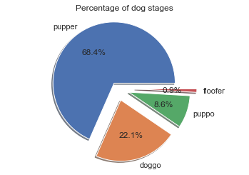

```python
# Creating pie chart
plt.pie(stage_df,
       labels = ['pupper', 'doggo', 'puppo', 'floofer'],
       autopct = '%1.1f%%',
       shadow = True,
       explode = (0.1, 0.2, 0.2, 0.3)
       )
plt.title('Percentage of dog stages')
plt.axis('equal')
```

### Insights:

1. Pupper has the highest percentage being 68.4%
2. floofer has the lowest percentage being 0.9%

### B. Relationship between retweet count and favourite count

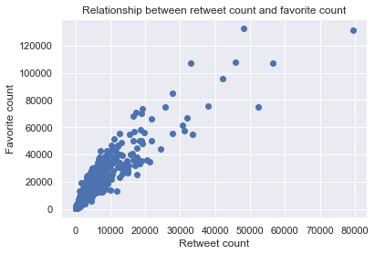

```python
plt.scatter(clean_df_1.retweet_count, clean_df_1.favorite_count)
plt.title('Relationship between retweet count and favorite count')
plt.xlabel('Retweet count')
plt.ylabel('Favorite count')
```

### Insights:

1. It appears that there is a linear relationship between both parameter